# PiotrMizinski

Piotr Miziński

6 marca 2019

# 1 Wstęp

W tej pracy domowej postaram się przeprowadzić eksplorację danych zbioru Allegro z pierwszego wykładu. Na początek przeanalizauję poszczególne kolumny, później wyłuskam i przedstawię kilka wybranych rankingów, a następnie zaprezentuję ich zmianę w czasie. Na koniec zilustruję przykładowe możliwości pakietu *visdata*.

# 2 Analiza zbioru

Po wczytaniu oraz połączeniu zbioru głównego i zawierającego nazwy kategorii powstał następujący zbiór, który poddano dalszej analizie (pokazano tylko 6 pierwszych wierszy):

```r
head(allegro2)
```

|  | date | item_id | categories | pay_option_on_delivery | pay_option_transfer | seller | price | it_is_allegro_standard | it_quantity | it_is_brand_zone | it_seller_rating | it_location | main_category |
| --- | --- | --- | --- | --- | --- | --- | --- | --- | --- | --- | --- | --- | --- |
| 1 | 2016-04-03 21:21:08 | 4753602474 | ['Komputery', 'Dyski i napędy', 'Nośniki', 'Nośniki DVD-R/RW', '30-50 szt. DVD-R/RW'] | 1 | 1 | radzioch666 | 59.99 | 1 | 997 | 0 | 50177 | Warszawa | Komputery |
| 2 | 2016-04-03 15:35:26 | 4773181874 | ['Odzież, Obuwie, Dodatki', 'Bielizna damska', 'Majtki'] | 1 | 1 | InwestycjeNET | 4.90 | 1 | 9288 | 0 | 12428 | Warszawa | Odzież, Obuwie, Dodatki |
| 3 | 2016-04-03 14:14:31 | 4781627074 | ['Dom i Ogród', 'Budownictwo i Akcesoria', 'Ściany i elewacje', 'Tapety', 'Fototapety'] | 1 | 1 | otostyl_com | 109.90 | 1 | 895 | 0 | 7389 | Leszno | Dom i Ogród |
| 4 | 2016-04-03 19:55:44 | 4783971474 | ['Książki i Komiksy', 'Poradniki i albumy', 'Zdrowie, pierwsza pomoc', 'Diety, zdrowy styl życia'] | 1 | 1 | Matfel1 | 18.50 | 0 | 971 | 0 | 15006 | Wola Krzysztoporska | Książki i Komiksy |
| 5 | 2016-04-03 18:05:54 | 4787908274 | ['Odzież, Obuwie, Dodatki', 'Ślub i wesele', 'Galanteria papiernicza', 'Pozostałe'] | 1 | 1 | PPHU_RICO | 19.90 | 1 | 950 | 0 | 32975 | BIAŁYSTOK | Odzież, Obuwie, Dodatki |
| 6 | 2016-04-03 16:31:01 | 4790991674 | ['Odzież, Obuwie, Dodatki', 'Bielizna damska', 'Pończochy'] | 1 | 1 | Noemi-bielizna | 10.99 | 1 | 742 | 0 | 39371 | GĄBIN | Odzież, Obuwie, Dodatki |

W celu szybkiego zorientowania się z jakimi kolumnami mamy do czynienia użyto na każdej z nich polecenia `summary` oraz `is.na`. Wyniki zaprezentowano poniżej.

```
##       date
##  Min.   :2016-04-03 00:00:09
##  1st Qu.:2016-04-03 12:50:14
##  Median :2016-04-03 17:12:25
##  Mean   :2016-04-03 16:24:21
##  3rd Qu.:2016-04-03 20:14:39
##  Max.   :2016-04-03 23:59:59
## Brakujące dane:[1] 0
##
##     item_id
##  Min.   :4.180e+09
##  1st Qu.:5.653e+09
##  Median :5.968e+09
##  Mean   :5.809e+09
##  3rd Qu.:6.071e+09
##  Max.   :6.100e+09
## Brakujące dane:[1] 0
##
##                                                               categories
##  ['Dom i Ogród', 'Ogród', 'Rośliny', 'Rośliny owocowe']            :  3753
##  ['Dom i Ogród', 'Ogród', 'Rośliny', 'Drzewa i krzewy liściaste']  :  2914
##  ['Dom i Ogród', 'Ogród', 'Rośliny', 'Bulwy, cebulki, kłącza']     :  2693
##  ['Odzież, Obuwie, Dodatki', 'Odzież damska', 'Sukienki']          :  2485
##  ['Motoryzacja', 'Opony', 'Opony samochodowe', 'Letnie']           :  2473
##  ['Telefony i Akcesoria', 'Akcesoria GSM', 'Folie ochronne na LCD']:  2293
##  (Other)                                                           :403409
## Brakujące dane:[1] 0
##
##  pay_option_on_delivery
##  Min.   :0.000
##  1st Qu.:1.000
##  Median :1.000
##  Mean   :0.878
##  3rd Qu.:1.000
##  Max.   :1.000
## Brakujące dane:[1] 0
##
##  pay_option_transfer
##  Min.   :0.0000
##  1st Qu.:1.0000
```

[output cut: 65 more lines]

```
##  Poznań   : 10610
##  Wrocław  :  8646
##  Białystok:  7356
##  (Other)  :344094
## Brakujące dane:[1] 0
##
##                  main_category
##  Dom i Ogród            : 91042
##  Odzież, Obuwie, Dodatki: 54257
##  Motoryzacja            : 45941
##  Dla Dzieci             : 42107
##  Uroda                  : 28096
##  Sport i Turystyka      : 27532
##  (Other)                :131045
## Brakujące dane:[1] 0
```

To proste polecenie dało ogólne pojęcie o zbiorze danych oraz zasugerowało w jakim kierunku może pójść nasza analiza, którą zaprezentowano w dlaszych rozdziałach.

# 3 Top5

W tym rozdziale zaprezentowano wykresy przedstawiające listy top5 wartości z danej dziedziny.

## 3.1 Top5 najdroższych kategorii

Na pierwszym wykresie pokazano top5 najbardziej dochodowych kategorii, z których sprzedawano produkty za pośrednictwem platformy allegro, pod względem sumy, a na drugim wykresie ze względu na średnią kwotę transakcji.

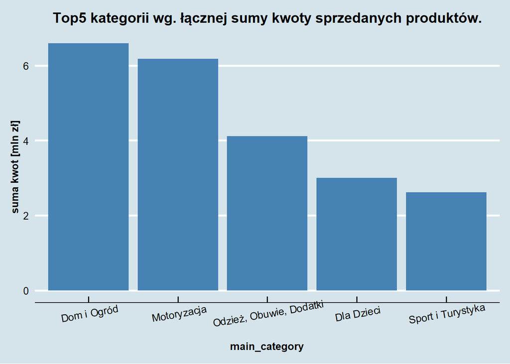

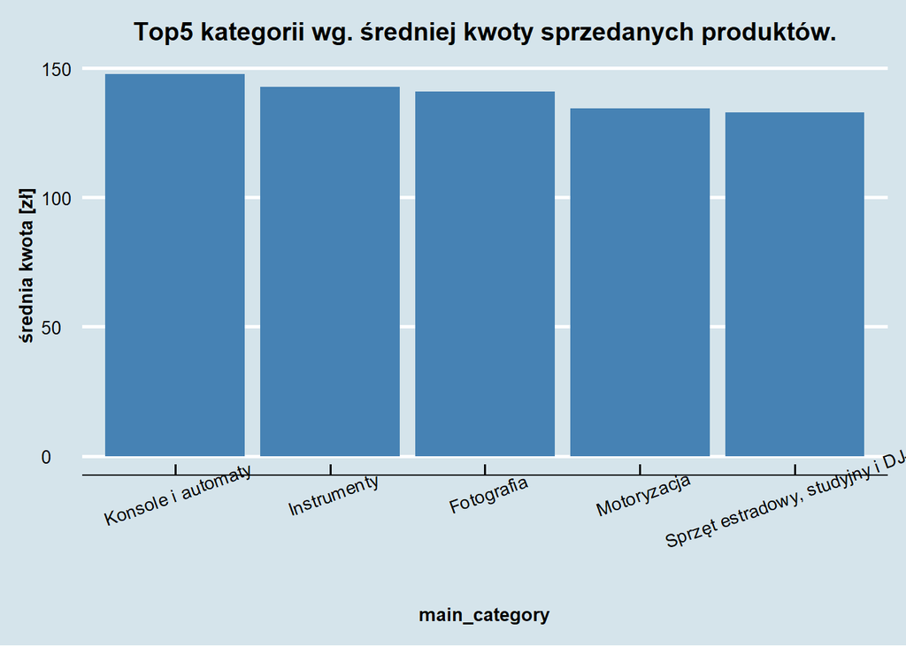

Jak możemy zauważyć jedynie jedna kategoria - *motoryzacja* powtarza się w obu zestawieniach. Dla top5 kategorii wykonano również wykresy *boxplot*, co zaprezentowano poniżej. Wykresy te wykonano względem logarytmu z ceny transakcji, aby były one bardziej przejrzyste i wygodne do wizualnego porównania.

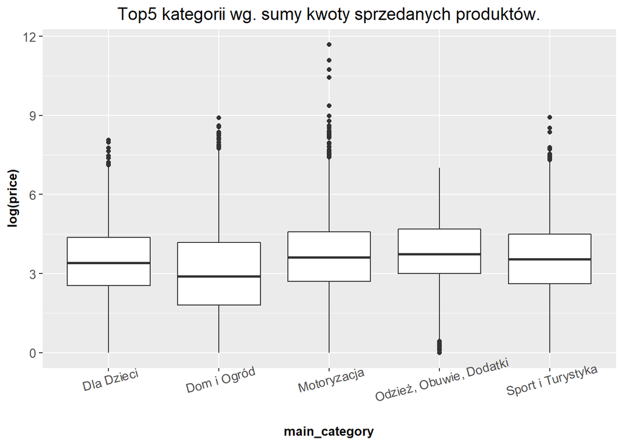

## 3.2 Top5 sprzedawców

Na pierwszym wykresie pokazano top5 sprzedawców, którzy dokonali najwięcej transakcji, a na drugim z największą sumą kwot transakcji.

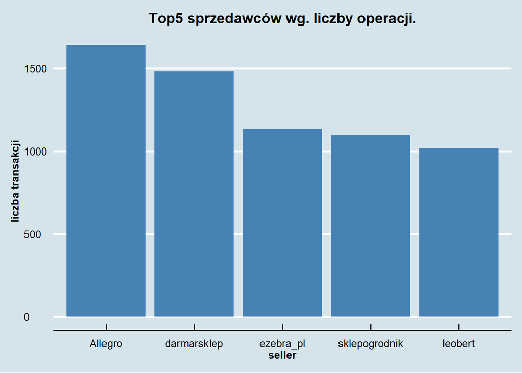

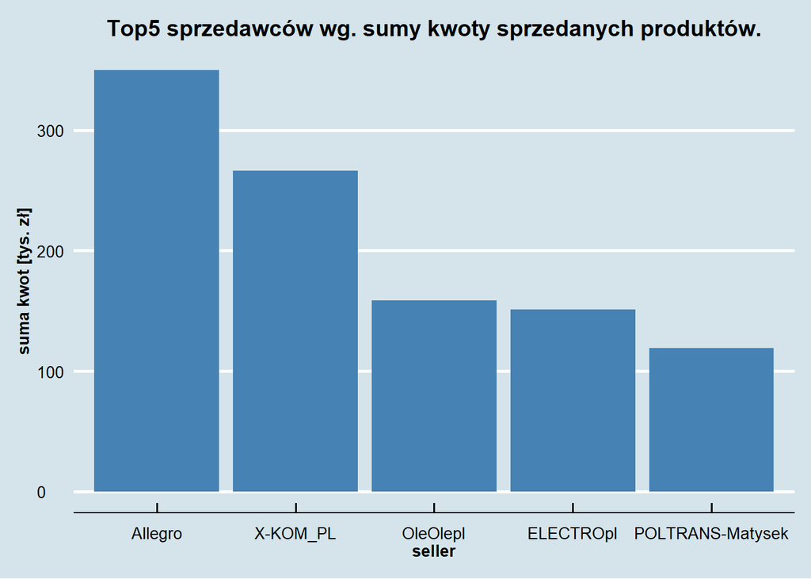

Jak widać dla obu tych miar prym wiedzie Allegro, a pozostałe miejsca się różnią. Dla top5 sprzedawców wykonano również wykresy *boxplot*, co zaprezentowano poniżej. Wykresy te wykonano względem logarytmu z ceny transakcji, aby były one bardziej przejrzyste i wygodne do wizualnego porównania.

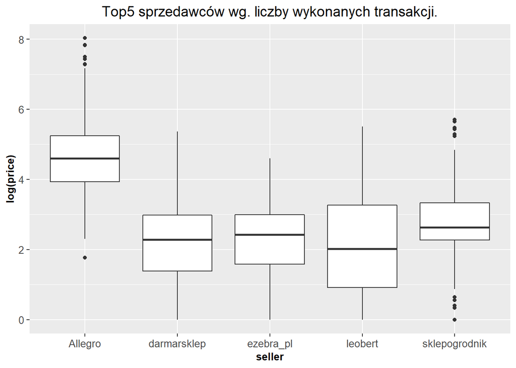

## 3.3 Top5 lokalizacji

Na pierwszym wykresie pokazano miejscowości, dla których przeprowadzono najwiecej transakcji, natomiast na drugim zaprezentowano miasta, dla których transakcje mają najwyższą średnią kwotę zakupu, przy czym wzięto pod uwage jedynie lokalizacjie z przynajmniej 1000 operacji.

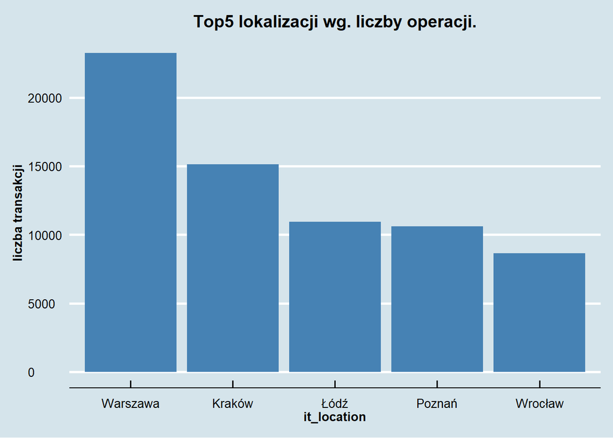

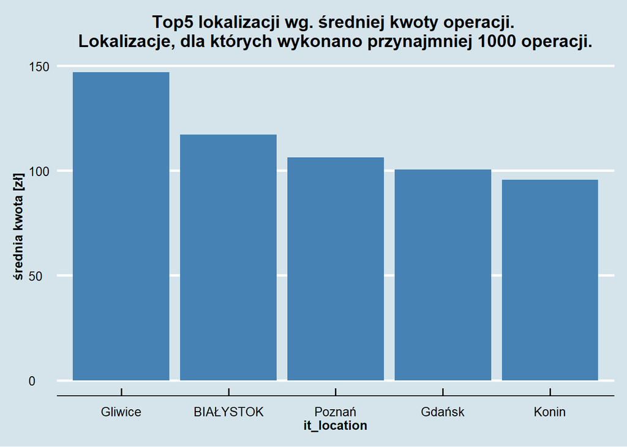

Jak można zauważyć w Warszawie dokonuje się najwięcej zakupów w serwisie Allegro, natomiast na obu wykresach pojawił się jedynie Poznań.

## 3.4 Top10 najdroższych

Poniżej pokazano 10 najdroższych transakcji.

|  | main_category | price | seller | it_location | it_quantity |
| --- | --- | --- | --- | --- | --- |
| 1 | Motoryzacja | 119000 | POLTRANS-Matysek | bodzentyn | 0 |
| 2 | Motoryzacja | 83000 | adamkac100 | Ostrów Mazowiecka | 0 |
| 3 | Motoryzacja | 64900 | iwka-2006 | Olawa | 0 |
| 4 | Motoryzacja | 63900 | Kubota3 | Warszawa | 0 |
| 5 | Motoryzacja | 52500 | zuzaziza | WARSZAWA | 0 |
| 6 | Motoryzacja | 46000 | el_kocurro | Gdańsk | 0 |
| 7 | Motoryzacja | 46000 | LubieYangi | łuków | 0 |
| 8 | Motoryzacja | 38000 | goskamarcin | Pabianice | 0 |
| 9 | Motoryzacja | 34000 | tadeusz14_11 | Baranów | 0 |
| 10 | Motoryzacja | 27000 | witek345 | Złoczew | 0 |

Jak widać wszystkie transakcjie dotyczyły motoryzacji.

Ta analiza, oprócz ciekawych wyników, skłoniła nas również do kolejnej analizy poprawności danych, a mianowicie zweryfikowania liczby transakcji, które mają wpisana liczbę jednostek równą 0.

```
## Liczba jednostek = 0:
```

```
## [1] 63480
```

# 4 Histogramy

W tym rozdziale pokazano dwa wykresy. Pierwszy z nich prezentuje rozkład liczby dokonywanych wszystkich transakcji w ciągu dnia. Drugi wykres zawierający kilka wykresów również pokazuje histogram transakcji, ale z podziałem na kategorie.

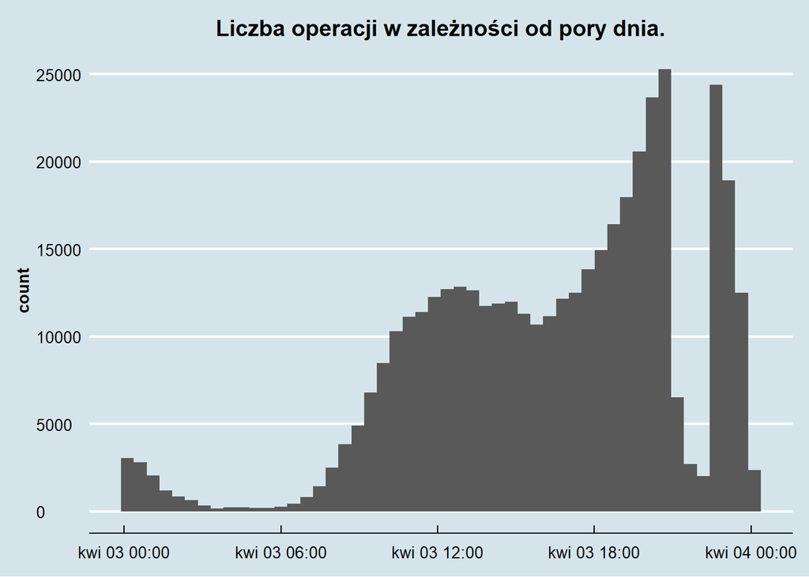

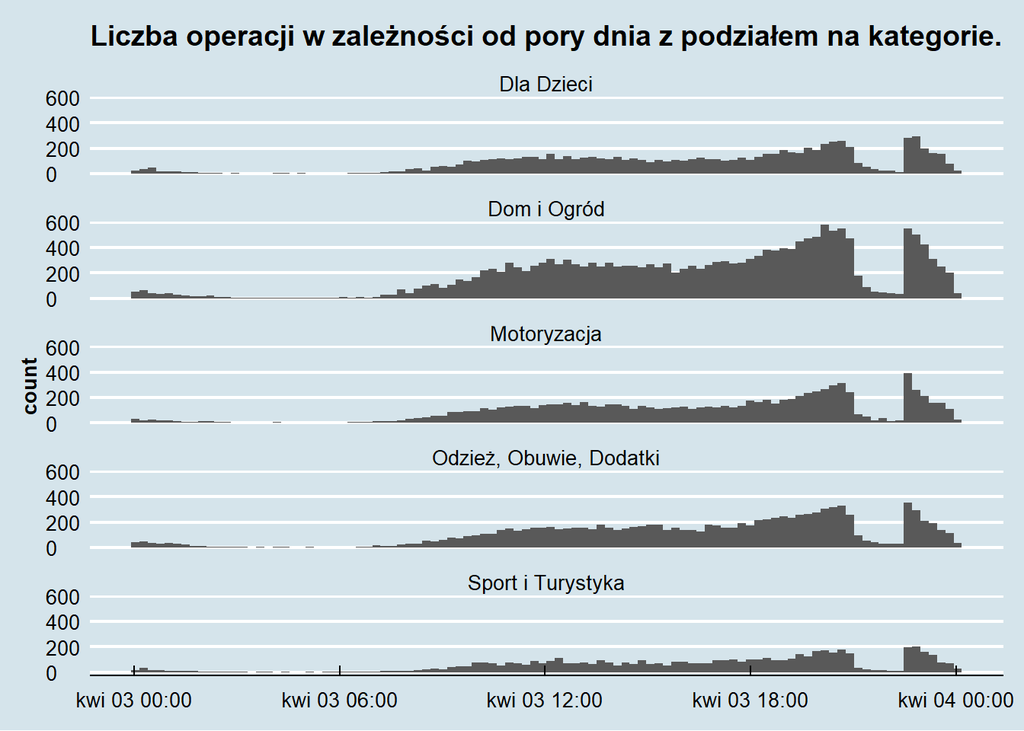

Jak widać na pierwszym wykresie liczba dokonywanych transakcji sukcesywnie rośnie od godziny 6, by ustabilizować się na moment około godziny 12 i następnie osiągnąć maksimum w godzinach wieczornych. Ciekawym jest wystąpienie chwilowego drastycznego spadku liczby zamówień około godziny 22. Może być to związane z przyczynami technicznymi i/lub migracyjnymi serwisu allegro. W godzinach nocnych nie obserwuje się wielu transakcji. Z drugiego wykresu widać, że główne kategorie zachowują trend podobny do ogólnego, a zmiany są ledwo zauważalne.

# 5 visdata

Na potrzeby tej pracy domowej zapoznano się z pakietem *visdata*, służącym do wizualizacji ramek danych, pomocnym przy ich analizie.

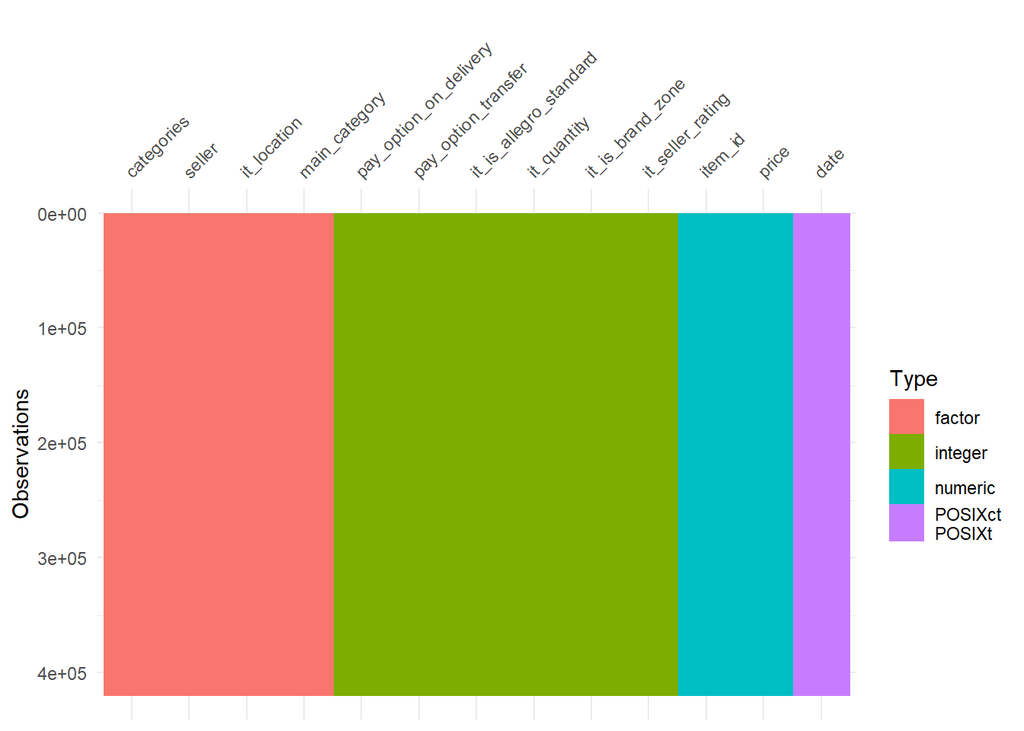

Polecenie `vis_miss()` potwierdza nasze przypuszczenia, zbiór danych jest kompletny - rysunek poniżej.

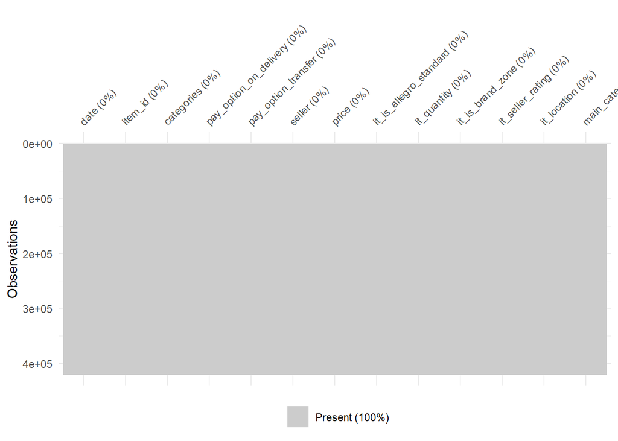

Ostatnim z poleceń, któe zdecydowano się zaprezentować jest `vis_cor()`, które pokazuje korelację zbioru danych, prezentując ją na atrakcyjnym wykresie, który zaprezentowano poniżej.

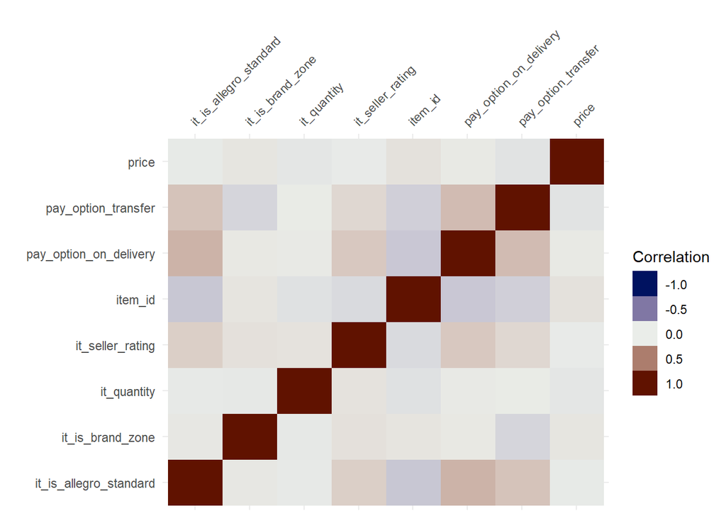

Pakiet `visdat` pozwala na szybką, wizualną analizę zbioru danych. Jest to atrakcyjny sposób na kontrolę danych i dowiedzenie się podstawowych informacji na ich temat.

# 6 Podsumowanie

Dzięki poleceniom i pakietom oferowanym przez język R można szybko sprawdzić poprawność, jakość i rodzaj danych zawartych w zbiorze danych i ewentualnie je poprawić. Pozwala on również na dogłębną analizę, która może powiedzieć nam wiele interesujących i przydatych rzeczy o danym zjawisku, które można później wykorzystać w praktyczny sposób. Na przykład analizując histogram operacji w ciągu dnia, możemy zdecydować w jakich godzinach wyświetlać dane reklamy, biorąc pod uwagę rozkłady dla różnych kategorii produktów.